# PML Project: Qualitative Activity Recognition

miniesta4

February 26, 2020

## Introduction

People regularly quantify how much of a particular activity is done, but they rarely quantify how well they do it. The goal of this project is to predict the manner in which six participants do the exercise named “Unilateral Dumbbell Biceps Curl” using data from accelerometers on the belt, forearm, arm and dumbbell.

Five different classes have been set. Only the A class is the correct manner:

- Class A: Exactly according to the specification
- Class B: Throwing the elbows to the front
- Class C: Lifting the dumbbell only halfway
- Class D: Lowering the dumbbell only halfway
- Class E: Throwing the hips to the front

The data for this project come from this source:  
http://web.archive.org/web/20161224072740/http:/groupware.les.inf.puc-rio.br/har

## Exploratory data analysis and pre-processing

Dimensions of the provided data set:

```
## [1] 19622   160
```

The data set is splitted into training and test set in order to estimate the test error rate under the validation set approach.

Traininng data set:

```
## [1] 14718   160
```

```
##
##    A    B    C    D    E
## 4185 2848 2567 2412 2706
```

First seven columns corresponds to variables which are not related to the way the exercise is performed. They are removed.

```
##   X user_name raw_timestamp_part_1 raw_timestamp_part_2   cvtd_timestamp
## 1 1  carlitos           1323084231               788290 05/12/2011 11:23
## 2 2  carlitos           1323084231               808298 05/12/2011 11:23
## 4 4  carlitos           1323084232               120339 05/12/2011 11:23
## 6 6  carlitos           1323084232               304277 05/12/2011 11:23
## 7 7  carlitos           1323084232               368296 05/12/2011 11:23
##   new_window num_window
## 1         no         11
## 2         no         11
## 4         no         12
## 6         no         12
## 7         no         12
```

Variables with a high proportion of NA’s are removed.

```
##    Min. 1st Qu.  Median    Mean 3rd Qu.    Max.
##  0.0000  0.0000  0.9793  0.6413  0.9793  1.0000
```

```
##
## FALSE  TRUE
##   100    53
```

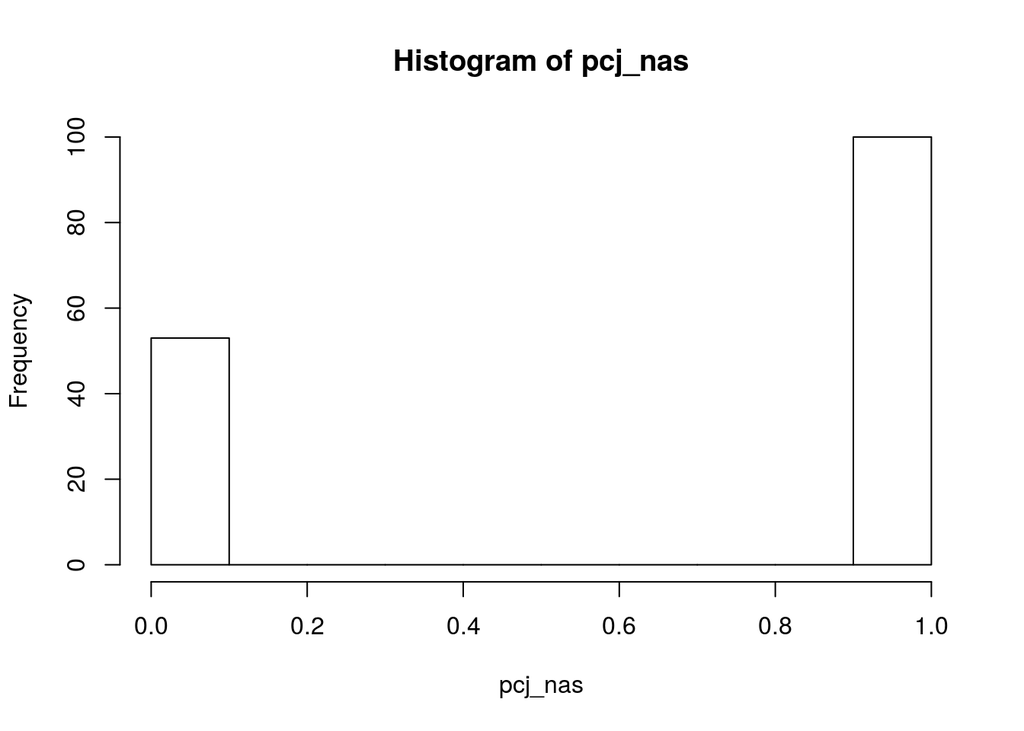

There are not variables with near zero variability.

```
## [1] freqRatio     percentUnique zeroVar       nzv
## <0 rows> (or 0-length row.names)
```

Final variables in the training set:

```
## [1] 14718    53
```

```
##  [1] "roll_belt"            "pitch_belt"           "yaw_belt"
##  [4] "total_accel_belt"     "gyros_belt_x"         "gyros_belt_y"
##  [7] "gyros_belt_z"         "accel_belt_x"         "accel_belt_y"
## [10] "accel_belt_z"         "magnet_belt_x"        "magnet_belt_y"
## [13] "magnet_belt_z"        "roll_arm"             "pitch_arm"
## [16] "yaw_arm"              "total_accel_arm"      "gyros_arm_x"
## [19] "gyros_arm_y"          "gyros_arm_z"          "accel_arm_x"
## [22] "accel_arm_y"          "accel_arm_z"          "magnet_arm_x"
## [25] "magnet_arm_y"         "magnet_arm_z"         "roll_dumbbell"
## [28] "pitch_dumbbell"       "yaw_dumbbell"         "total_accel_dumbbell"
## [31] "gyros_dumbbell_x"     "gyros_dumbbell_y"     "gyros_dumbbell_z"
## [34] "accel_dumbbell_x"     "accel_dumbbell_y"     "accel_dumbbell_z"
## [37] "magnet_dumbbell_x"    "magnet_dumbbell_y"    "magnet_dumbbell_z"
## [40] "roll_forearm"         "pitch_forearm"        "yaw_forearm"
## [43] "total_accel_forearm"  "gyros_forearm_x"      "gyros_forearm_y"
## [46] "gyros_forearm_z"      "accel_forearm_x"      "accel_forearm_y"
## [49] "accel_forearm_z"      "magnet_forearm_x"     "magnet_forearm_y"
## [52] "magnet_forearm_z"     "classe"
```

```
##
##    A    B    C    D    E
## 4185 2848 2567 2412 2706
```

The correlation matrix shows that some variables are highly correlated. This situation is known as “Collinearity”. It can pose problems in the regression context.

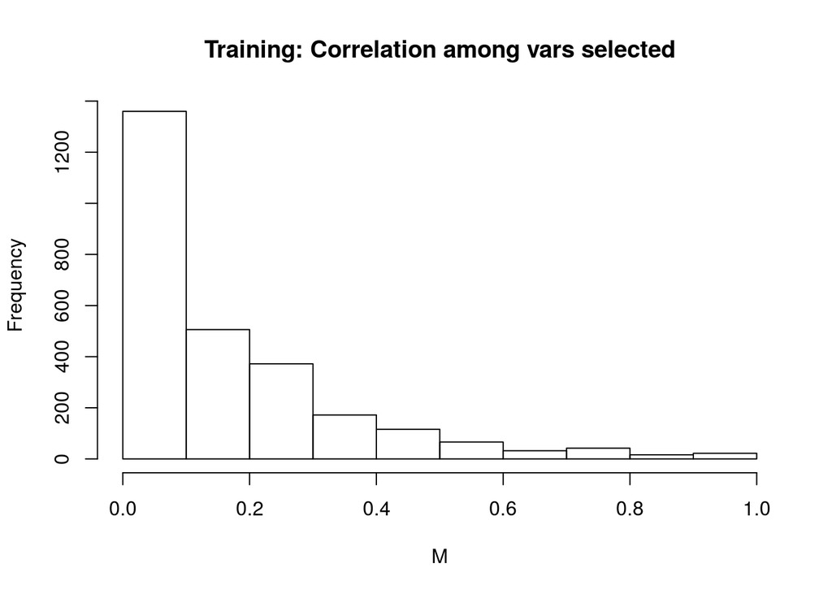

Variables with correlation > 0.9:

```
##                  row col
## total_accel_belt   4   1
## accel_belt_y       9   1
## accel_belt_z      10   1
## accel_belt_x       8   2
## roll_belt          1   4
## accel_belt_y       9   4
## accel_belt_z      10   4
## pitch_belt         2   8
## roll_belt          1   9
## total_accel_belt   4   9
## accel_belt_z      10   9
## roll_belt          1  10
## total_accel_belt   4  10
## accel_belt_y       9  10
## gyros_arm_y       19  18
## gyros_arm_x       18  19
## gyros_dumbbell_z  33  31
## gyros_forearm_z   46  31
## gyros_dumbbell_x  31  33
## gyros_forearm_z   46  33
## gyros_dumbbell_x  31  46
## gyros_dumbbell_z  33  46
```

## Model selection

Collinearity advises against the use of regression models. Tree-based methods are simple and useful for interpretation. A tree-based method named CART will be used.

### Classification tree

A classification tree predicts that each observation belongs to the most commonly occurring class of training observations in the region to which it belongs.

```
## CART
##
## 14718 samples
##    52 predictors
##     5 classes: 'A', 'B', 'C', 'D', 'E'
##
## No pre-processing
## Resampling: Bootstrapped (25 reps)
## Summary of sample sizes: 14718, 14718, 14718, 14718, 14718, 14718, ...
## Resampling results across tuning parameters:
##
##   cp          Accuracy   Kappa
##   0.03465300  0.4941972  0.33756320
##   0.05924238  0.3949520  0.17414188
##   0.11288332  0.3311425  0.07267593
##
## Accuracy was used to select the optimal model using the largest value.
## The final value used for the model was cp = 0.034653.
```

Final model:

[figure not shown]

Evaluation on the test set.

```
## Confusion Matrix and Statistics
##
##           Reference
## Prediction    A    B    C    D    E
##          A 1268  391  383  341  134
##          B   23  336   24  150  110
##          C  101  222  448  313  226
##          D    0    0    0    0    0
##          E    3    0    0    0  431
##
## Overall Statistics
##
##                Accuracy : 0.5063
##                  95% CI : (0.4922, 0.5204)
##     No Information Rate : 0.2845
##     P-Value [Acc > NIR] : < 2.2e-16
##
##                   Kappa : 0.3553
##
##  Mcnemar's Test P-Value : NA
##
## Statistics by Class:
##
##                      Class: A Class: B Class: C Class: D Class: E
## Sensitivity            0.9090  0.35406  0.52398   0.0000  0.47836
## Specificity            0.6441  0.92238  0.78711   1.0000  0.99925
## Pos Pred Value         0.5038  0.52255  0.34198      NaN  0.99309
## Neg Pred Value         0.9468  0.85614  0.88676   0.8361  0.89485
## Prevalence             0.2845  0.19352  0.17435   0.1639  0.18373
## Detection Rate         0.2586  0.06852  0.09135   0.0000  0.08789
## Detection Prevalence   0.5133  0.13112  0.26713   0.0000  0.08850
## Balanced Accuracy      0.7765  0.63822  0.65554   0.5000  0.73880
```

Accuracy on the test set is very close to the expected accuracy.

### Boosting

Boosting is an approach for improving prediction results from decision trees. It is based on growing trees sequentially, using information from previously grown trees and then combining all of the trees in order to create a single predictive model.

```
## Stochastic Gradient Boosting
##
## 14718 samples
##    52 predictors
##     5 classes: 'A', 'B', 'C', 'D', 'E'
##
## No pre-processing
## Resampling: Bootstrapped (25 reps)
## Summary of sample sizes: 14718, 14718, 14718, 14718, 14718, 14718, ...
## Resampling results across tuning parameters:
##
##   interaction.depth  n.trees  Accuracy   Kappa
##   1                   50      0.7497963  0.6826449
##   1                  100      0.8157814  0.7667456
##   1                  150      0.8494963  0.8094631
##   2                   50      0.8539128  0.8148852
##   2                  100      0.9047076  0.8793629
##   2                  150      0.9299266  0.9112990
##   3                   50      0.8949266  0.8669389
##   3                  100      0.9398733  0.9238956
##   3                  150      0.9573199  0.9459825
##
## Tuning parameter 'shrinkage' was held constant at a value of 0.1
##
## Tuning parameter 'n.minobsinnode' was held constant at a value of 10
## Accuracy was used to select the optimal model using the largest value.
## The final values used for the model were n.trees = 150, interaction.depth =
##  3, shrinkage = 0.1 and n.minobsinnode = 10.
```

Evaluation on the test set.

```
## Confusion Matrix and Statistics
##
##           Reference
## Prediction    A    B    C    D    E
##          A 1373   35    0    0    3
##          B   12  889   32    7    9
##          C    9   24  819   35   11
##          D    0    1    4  758    9
##          E    1    0    0    4  869
##
## Overall Statistics
##
##                Accuracy : 0.96
##                  95% CI : (0.9542, 0.9653)
##     No Information Rate : 0.2845
##     P-Value [Acc > NIR] : < 2.2e-16
##
##                   Kappa : 0.9494
##
##  Mcnemar's Test P-Value : NA
##
## Statistics by Class:
##
##                      Class: A Class: B Class: C Class: D Class: E
## Sensitivity            0.9842   0.9368   0.9579   0.9428   0.9645
## Specificity            0.9892   0.9848   0.9805   0.9966   0.9988
## Pos Pred Value         0.9731   0.9368   0.9120   0.9819   0.9943
## Neg Pred Value         0.9937   0.9848   0.9910   0.9889   0.9921
## Prevalence             0.2845   0.1935   0.1743   0.1639   0.1837
## Detection Rate         0.2800   0.1813   0.1670   0.1546   0.1772
## Detection Prevalence   0.2877   0.1935   0.1831   0.1574   0.1782
## Balanced Accuracy      0.9867   0.9608   0.9692   0.9697   0.9816
```

## Conclusion

Accuracy has vastly improved from around 0.50 to 0.96 with the introduction of Boosting.

## Source code

Link to the source code repository:  
https://github.com/miniesta4/datasciencecoursera